# Introduction to the `hpiR` package

### Index Series

Two other aspects or metrics of house price indexes are revision and forecast accuracy. Forecast accuracy refers to how well an index forecast captures future market movements. Revision refers to how much original index values change over time as new data is accumulated (new transactions occur). Both concepts are described more fully below. To calculate either of these metrics requires a series of indexes.

A series of indexes is a collection of progressively longer indexes that are estimated over time, or estimated sequentially such that the knowledge of the future is withheld from the model. For example, imagine we have, as the example below does, 84 months (periods) of data. Since we are using a statistical modeling approach, let’s assume that we need at least 12 period of data (training period) to fit a model. We begin by creating an index for periods 1 through 12, assuming that we only have data from periods 1 through 12. Then we do 1 through 13, assuming we only have data from periods 1 through 13; on up to period 84. This represents an index series. The indexes in the series are identified by the number of the last period that they are estimating, index 12, index 13, etc.

The `createSeries()` function will create these series. The `hpi_obj` argument must be a full `hpi` object (created with one of the index wrappers). `train_period` sets how many periods to use for initial training (length of the shortest period). The `max_period` argument (default is the entire length of existing index) will control the end period to estimate a series up to (defaults to the original length of the index in the `hpi` object.).

The `createSeries()` function will return an object of class `serieshpi` (data plus a series of `hpi` objects).

```r
   rt_series <- createSeries(hpi_obj = rt_hpi,
                             train_period = 24,
                             max_period = 30)
```

A series can be plotted with the `plot.serieshpi()` method.

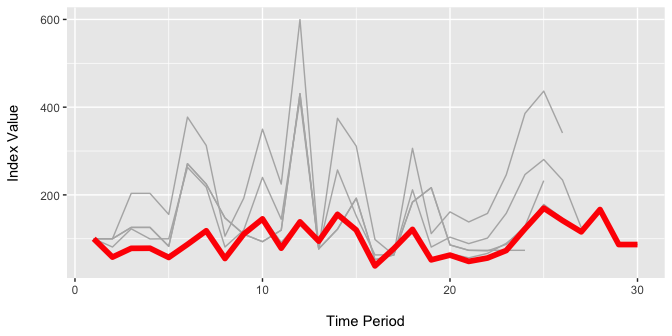

```r
  plot(rt_series)
```

#### Series Analysis

A wrapper function, `smoothSeries()` will smooth all `hpiindex` objects in a series. The smoothing will occur “in place” and a series object will be returned by the function.

```r
  rt_series <- smoothSeries(series_obj = rt_series,
                             order = 5)
```

A wrapper function, `calcSeriesVolatility()` will calculate volatility for all `hpiindex` objects in a series. The calculations will occur “in place” and a series object will be returned by the function. Can be done on smoothed indexes as well (`smooth = TRUE`)

```r
  rt_series <- calcSeriesVolatility(series_obj = rt_series,
                                    window = 3,
                                    smooth = TRUE)
```

A wrapper function, `calcSeriesAccuracy()` will calculate accuracy for all `hpiindex` objects in a series and return to an object of class `seriesaccuracy`. Smoothed indexes can be evaluated as well (`smooth = TRUE`)

```r
  rt_sacc <- calcSeriesAccuracy(series_obj = rt_series,
                                test_method = 'insample',
                                test_type = 'rt')
  class(rt_sacc)
```

```
## [1] "seriesaccuracy" "hpiaccuracy"    "data.frame"
```

These calculations can occur “in place” and a series object will be returned by the function. Note that running this function on the “kfold” method may be computationally intense depending on your data size and index length. Unlike index accuracy calculations which are saved in the `hpiindex` object, series accuracy calculations are saved in the `serieshpi` object when done “in place”.

```r
  rt_series <- calcSeriesAccuracy(series_obj = rt_series,
                                  test_method = 'kfold',
                                  test_type = 'rt',
                                  smooth = TRUE,
                                  in_place=TRUE)
```

One thing to note about series accuracy is that the training data will be evaluated separated for each index in the series, meaning that there will be many prediction errors for each observation. By setting `summarize = TRUE`, the mean for each observation will be calculated.

```r
  series_acc_summ <- calcSeriesAccuracy(series_obj = rt_series,
                                        test_method = 'insample',
                                        test_type = 'rt',
                                        summarize = TRUE)
  nrow(series_acc_summ)
```

```
## [1] 35
```

```r
  nrow(rt_series$accuracy)
```

```
## [1] 189
```

#### Forecast Accuracy

A final way to estimate accuracy is with a forecast test. In a forecast test, we use a series of indexes and continue to predict one period ahead and measure how well the predicted index does against repeated transactions in that period. In highly volatile or cyclical markets this is the most representative method of the answering the question: “how well does this index represent the near future?”

As above, it can be used on the raw index values or the smoothed ones (`smooth = TRUE`). The forecast accuracy tests are saved in the `serieshpi` object.

```r
  rt_series <- calcSeriesAccuracy(series_obj = rt_series,
                                  test_method = 'forecast',
                                  test_type = 'rt',
                                  smooth = TRUE,
                                  in_place = TRUE)
```

We can plot the `seriesaccuracy` objects, which look nearly identical to `hpiaccuracy` objects.

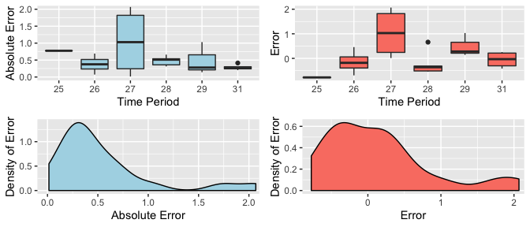

```r
  plot(rt_series$accuracy_smooth)
```

#### Revision

As can be the case with house price indexes, the estimated index values move considerably as new data (transactions) are accumulated over time. We can measure the amount of this change, or ‘revision’ over time as a useful metric or property of the series or of the final index.

Within the literature on house price indexes there is no standard or agreed upon metric to summarize revision. Here we do it two ways. First, at the period level where we calculate the average revision (change from period to period) for each period in the series of indexes. Obviously, the earlier period have a larger sample size (though they do have more time to be influenced by future transactions) than the latter periods are and, as such, are likely to be less volatile.

The second calculation simply averages all revisions across all periods to provide a single value of the average and median revision for the index series.

```r
  # Return to a revision object
  rt_rev <- calcRevision(series_obj = rt_series)

  # Return in place (with smooth)
  rt_series <- calcRevision(series_obj = rt_series,
                            in_place = TRUE,
                            smooth = TRUE)
  names(rt_series)
```

```
## [1] "data"            "hpis"            "volatility"      "accuracy_smooth"
## [5] "revision_smooth"
```

We can plot the revisions with the `plot.hpirevision()` method to show the average revision by time period. The `measure argument (default = *“median”*) determines whether median or mean revisions will be shown.

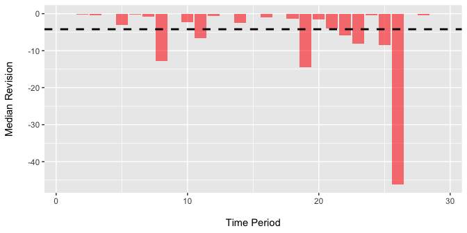

```r
  plot(rt_rev, measure='median')
```

More information on the class structures of the object created above can be found in the “Classes in hpiR” vignette in this package.

### Random Forest

The third approach to creating a house price index is a random forest combined with a post-model interpretability method. To date, partial dependence calculations are the sole ‘estimator’ type. More information on this approach and its comparison to the approaches above can be found in the paper at: https://www.github.com/andykrause/hpi_research/tree/master/irf/papers

Like the indexes above, the `rfIndex` function takes a number of arguments to define how to specify the index. However, there are two additional parameters:

- Simulation count: the number of properties to simulate to create the index. This can be done via one of three ways (arguments) – adding none of these will simulate all properties:
  - **sim_count**: Total number of simulations to do (will randomly choose)
  - **sim_ids**: The exact row ids to use in simulation
  - **sim_per**: The percentage of rows to simulate (will randomly choose)
- **ntrees**: Number of trees to grow in the random forest. Some initial testing showed little change in results for this dataset after about 150 trees.

```r
   rf_index <- rfIndex(trans_df = sales_hhdf,
                       date = 'sale_date',
                       price = 'sale_price',
                       trans_id = 'sale_id',
                       prop_id = 'pinx',
                       estimator = 'pdp',
                       periodicity = 'monthly',
                       dep_var = 'price',
                       ind_var = c('tot_sf', 'beds', 'baths'),
                       smooth = FALSE,
                       sim_ids = 1:10,
                       ntrees = 16)
```

This function returns results in a structured list similar to the repeat transaction and hedonic model approaches discussed above,

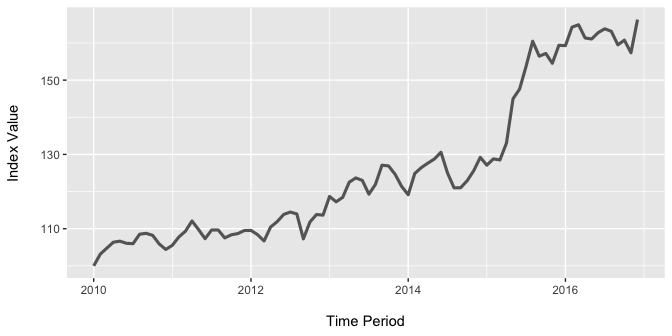

```r
  plot(rf_index)
```

[^1]: A small amount of data cleaning has gone into the creating the data, for more information on this process please contact the author.
[^2]: Note that a second method using hedonic pricing models is being developed.